# Homework #1

See all that stuff above. You should change `theme` and `highligh-style` to fit your own style. You can find them here: https://quarto.org/docs/output-formats/html-themes.html

Seriously, you should start finding your own style, so definitely change them!

++ I honestly like just vapor, I checked them all, morph came close, but I’ll just stick to vapor.

## Data

You’ll be working with the following data files:

- `artist_genre.txt`
- `artist_name.csv`
- `artist_net_worth.csv`
- `artist_number_one_hits.csv`
- `artist_studio_albums.csv`
- `artist_top_hits.csv`

The only file that you are going to need to be careful about is the `artist_genre` file – be sure to look at the extension and refer to the notes!

## Goals

- Read each file and join them together.

```r
artist_genre <- read.table("C:/Users/gayat/Downloads/artist_genre.txt",
                           header = TRUE)
View(artist_genre)
# As this is a text file, I have used read table to covert it into a R studio readable format.

artist_name <- read.csv("C:/Users/gayat/Downloads/artist_name.csv")

artist_net_worth <- read.csv("C:/Users/gayat/Downloads/artist_net_worth.csv")

artist_number_one_hits <- read.csv("C:/Users/gayat/Downloads/artist_number_one_hits.csv")

artist_studio_albums <- read.csv("C:/Users/gayat/Downloads/artist_studio_albums.csv")

artist_top_hits <- read.csv("C:/Users/gayat/Downloads/artist_top_hits.csv")

data_table <- merge(x = artist_genre, y = artist_name, by = "Artist")
df1 <- merge(x = data_table, y = artist_net_worth, by = "Artist")
df2 <- merge(x = df1, y = artist_number_one_hits, by.x = "Artist", by.y = "artist")
df3 <- merge(x = df2, y = artist_studio_albums, by = "Artist")
df4 <- merge(x = df3, y = artist_top_hits, by = "Artist")
# I did rolling merge, to join all data frames for better analysis
# and data convenience.
df4$artist = NULL
#I used the NULL value here to remove the duplicate artist table

df4_unique <- df4[!duplicated(df4), ]
#to eliminate all the duplicates from the table, I used the duplicate R base function.
```

- Create variables to capture the following ideas:
  - How long has the artist been around? You can just use their birth year.

```r
current_year <- 2023

Age <- current_year - df4_unique$Birth_Year
my_data <- cbind(df4_unique, Age)
# I found the age by simply subtracting the Birth Year from the current year.
#I pu current year separately as it allows me to run this code in the future as well, and I just have to change that number and not the entire code.
```

```
+ Something to capture each artist's net worth per studio album.
```

```r
net_worth_millions <- my_data$net_worth_millions
studio_albums <- my_data$studio_albums

x <- as.numeric(net_worth_millions)
y <- as.numeric(studio_albums)

net_worth_per_studio_album <- x / y
my_data <- cbind(my_data, net_worth_per_studio_album)
#I used simple math to find each artist's net worth, by dividing the net worth by the number of studio albums.
```

```
+ How old was each artist when they had their biggest hit?
```

```r
Biggest_hit_artist_age <- my_data$Year - my_data$Birth_Year
my_data <- cbind(my_data, Biggest_hit_artist_age)
# I found this by calculating the difference between the artist's birth year and their year of their biggest hit.
```

- Which artist has been around the longest?

```r
Highest_age <- max(Age)
Oldest_artist <- which(my_data$Age == Highest_age)
Oldest_artist <- my_data$Artist[Oldest_artist]
# This was a bit tricky for me. It took me sometime to figure out. I felt SQL is much easier for such questions i.e, to pull out data.
#However, I used which function to determine the condition and did the rest of the code with simple R.
```

- Which artists are above the mean of net worth per studio album?

```r
mean_artist <- mean(net_worth_per_studio_album, na.rm = TRUE)
with_artist_name <- my_data$Artist > mean_artist
artist_above_mean <- my_data$Artist[with_artist_name]
#I used the mean function extensively here.
```

- Plot net worth per studio album, the “been around” variable, and genre. There should be points and colors here.

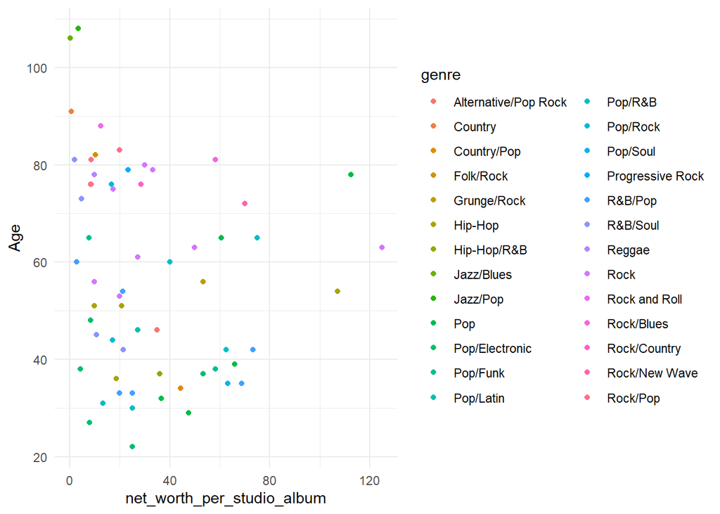

```r
library(ggplot2)
ggplot(my_data, aes(x = net_worth_per_studio_album, y = Age, color = genre)) +
geom_point(position = "dodge") +
theme_minimal()+
scale_colour_hue()
```

```r
#I wanted a colorful chart, so used geom point and created a scatterplot with the color references to genre.
```

- Show me something. There is a nice chunk of data here and you’ve got to have some neat ideas!

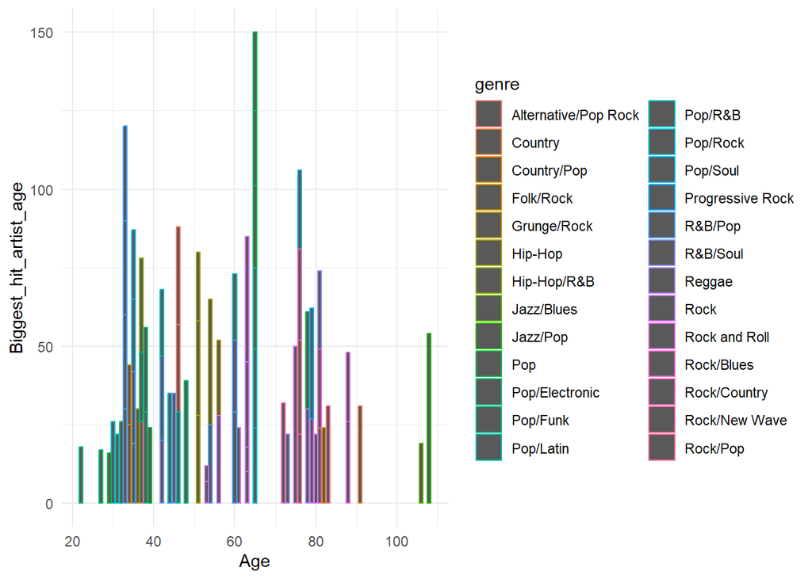

```r
library(ggplot2)
ggplot(my_data, aes(x = Age, y = Biggest_hit_artist_age, color = genre))+
geom_bar(stat = "identity")+
theme_minimal()+
scale_colour_hue()
```

```r
# I wanted to experiment here a bit. My exact intention here was to find at which age did artist's or for that matter most artist's get their success. I did not change the color reference from genre and tried to use a bar chart.
```

- Comment and explain everything! library(ggplot2) rmarkdown::paged_table